# Probability Work

D. Zeitler

September 7, 2017

We’re just going to explore probabilities and random numbers with R and mosaic.

```r
library(tidyverse)
library(mosaic)
library(ggformula)
```

R provides several probability distributions with associated functions.

- d: density or probability
- q: quantile
- p: cumulative probability
- r: sample random values

Along with the extensive probability calculations provided in R, the mosaic package provides a couple of useful functions.

*xp: cumulative probability (right and left tail) with graphic* plot: plots pdf/pmf or cdf

# First we will go through basic R probability, then mosaic stuff.

Getting the probability for Z between -1.96 and 1.96 is easy:

Subtracting the probability in the tails from one.

```r
1-pnorm(-1.96)*2
```

```
## [1] 0.9500042
```

Using the definition, subtract the cdf at the lower limit from the cdf at the upper limit.

```r
pnorm(1.96) - pnorm(-1.96)
```

```
## [1] 0.9500042
```

## Reverse probabilities

We used 1.96, that’s an approximate 95% value. Get the z-value that gives us exactly 0.95, not just close.

```r
qnorm(.025)
```

```
## [1] -1.959964
```

Or if we don’t want to think about removing that negative sign…

```r
qnorm(1-.025)
```

```
## [1] 1.959964
```

These are all using left tail probabilities. We can easily do right tail probabiliteis.

```r
pnorm(1.96,lower.tail = FALSE)
```

```
## [1] 0.0249979
```

```r
qnorm(.025,lower.tail = FALSE)
```

```
## [1] 1.959964
```

Another neat trick is to put the value right into my text, say here: 1.959964.

# Maybe some graphics and summaries

```
##      speed           dist
##  Min.   : 4.0   Min.   :  2.00
##  1st Qu.:12.0   1st Qu.: 26.00
##  Median :15.0   Median : 36.00
##  Mean   :15.4   Mean   : 42.98
##  3rd Qu.:19.0   3rd Qu.: 56.00
##  Max.   :25.0   Max.   :120.00
```

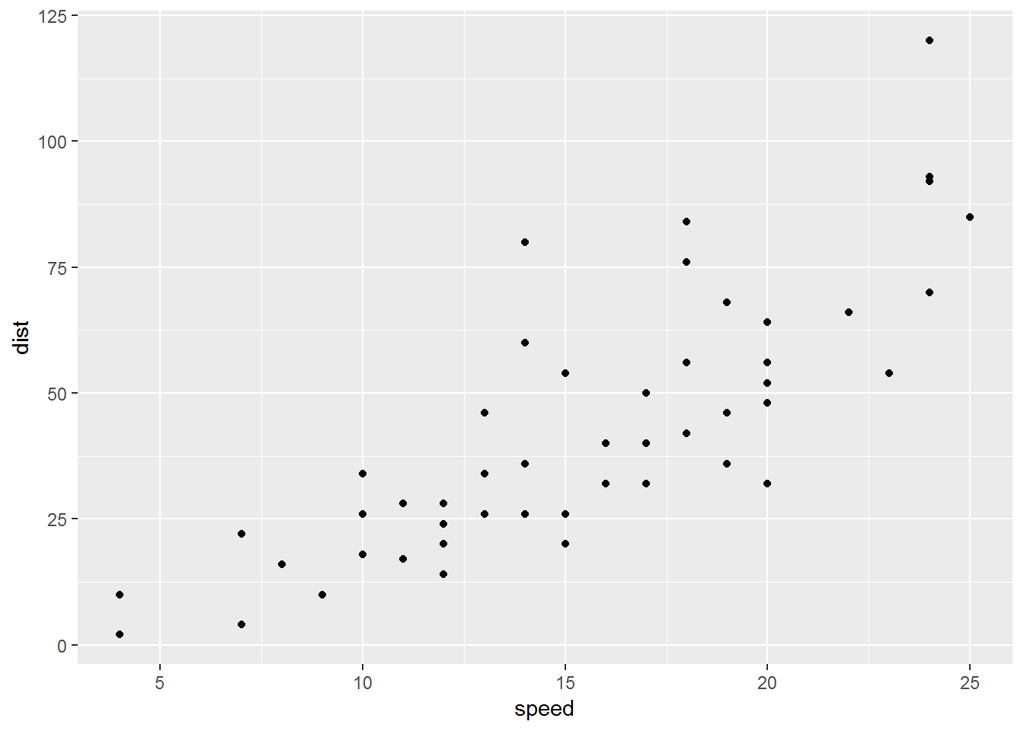

# Look at speed

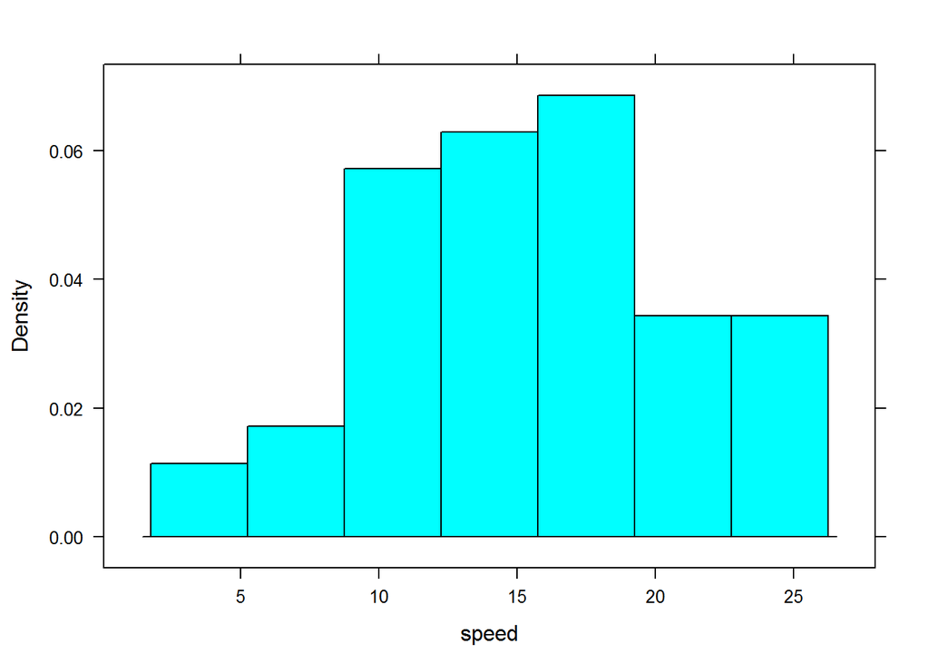

```r
histogram(~speed,data=cars)
```

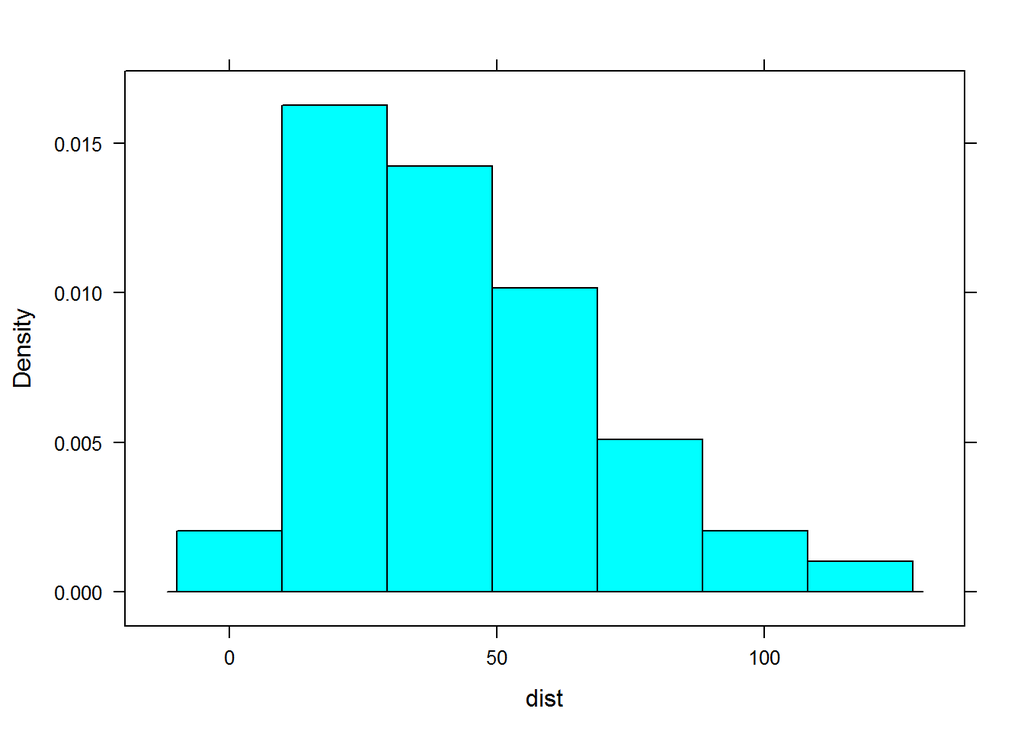

```r
histogram(~dist,data=cars)
```

Although we can assess normality by looking at the histogram, a better way is to use a quantile plot.

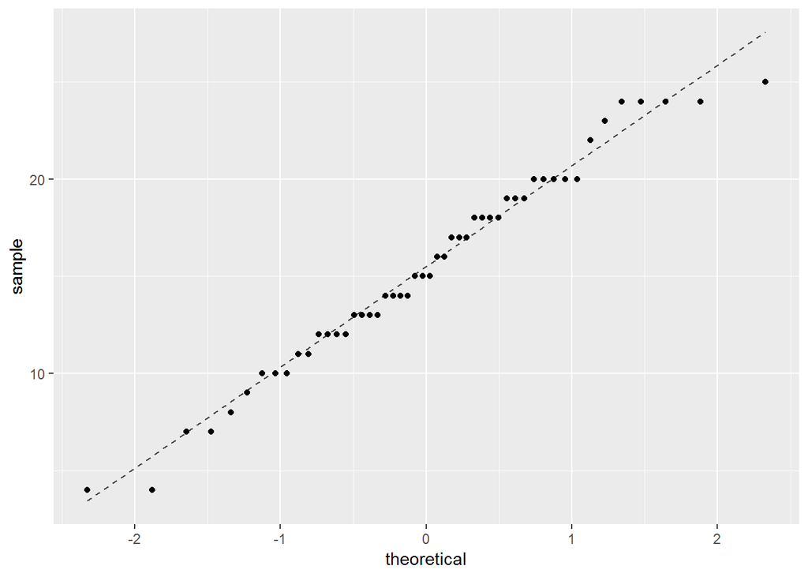

```r
gf_qq(~speed,data=cars) %>%
  gf_qqline(~speed,data=cars)
```

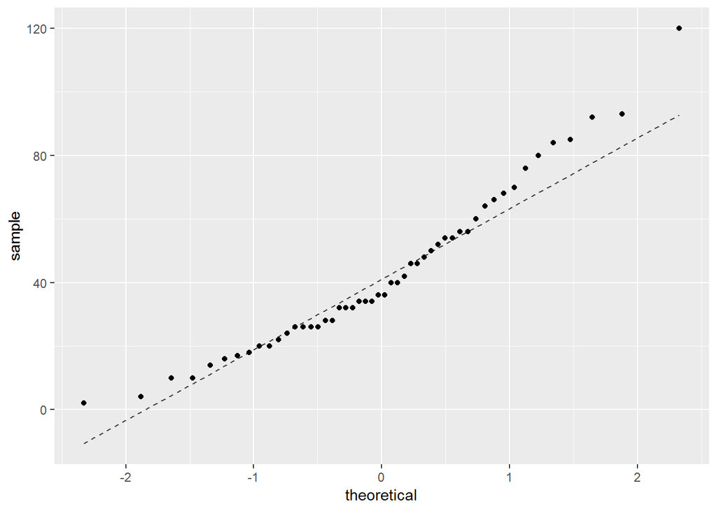

```r
gf_qq(~dist,data=cars) %>%
  gf_qqline(~dist,data=cars)
```

# further probability stuff

Let’s say we’re making widgets. They’re produced with a mean diameter 34 and standard deviation of 3.

What is the probability of getting widgets that are smaller than 24.

```r
pnorm(24,lower.tail = T,mean = 34, sd = 3)
```

```
## [1] 0.0004290603
```

# integrating

Probability Z < 0.

```r
integrate(dnorm, -Inf, 0)
```

```
## 0.5 with absolute error < 4.7e-05
```

# mosaic functions

## xpnorm

```r
xpnorm(1.96, mean=0, sd=1)
```

```
## If X ~ N(0, 1), then
```

```
##  P(X <= 1.96) = P(Z <= 1.96) = 0.975
```

```
##  P(X >  1.96) = P(Z >  1.96) = 0.025
```

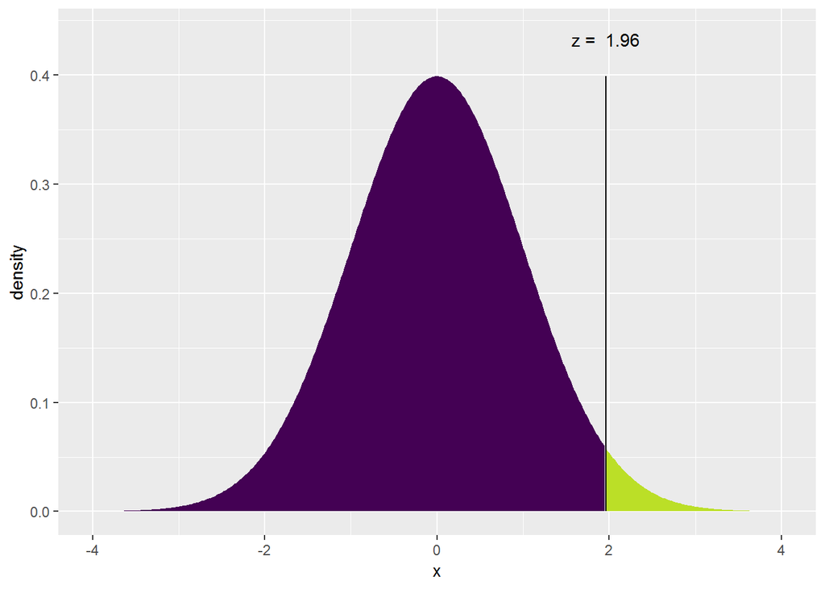

```
## [1] 0.9750021
```

## plotDist

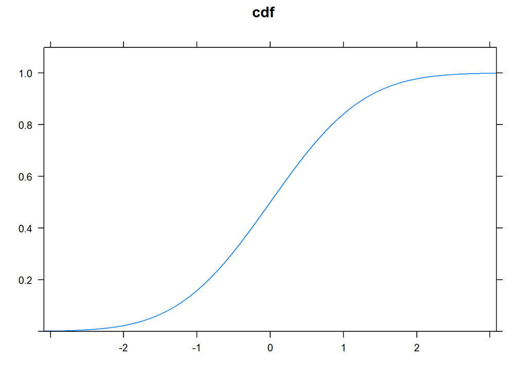

```r
plotDist('norm', mean=0, sd=1, kind='cdf',main='cdf')
```

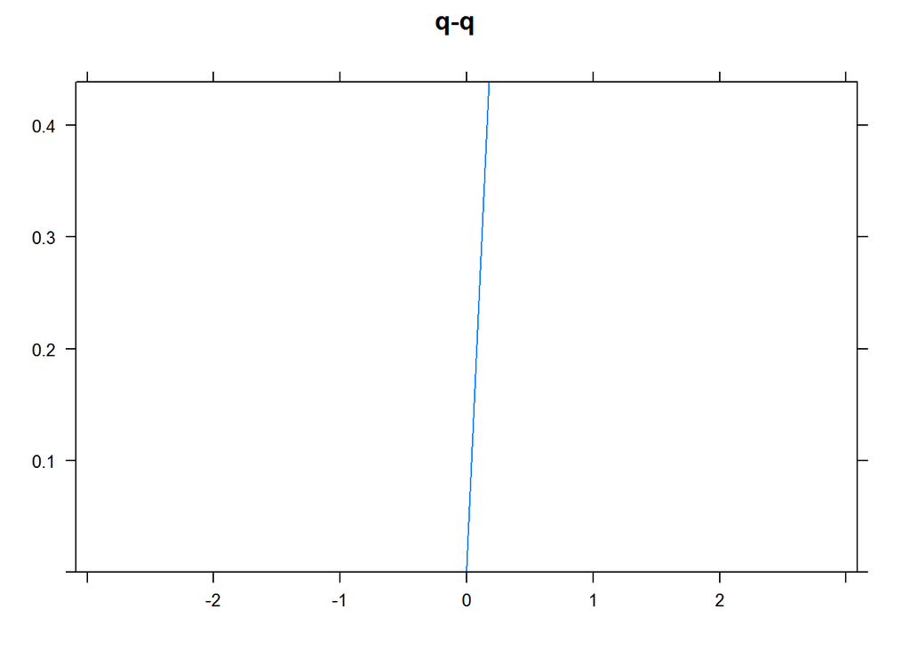

```r
plotDist('norm', mean=0, sd=1, kind='qq',main='q-q')
```

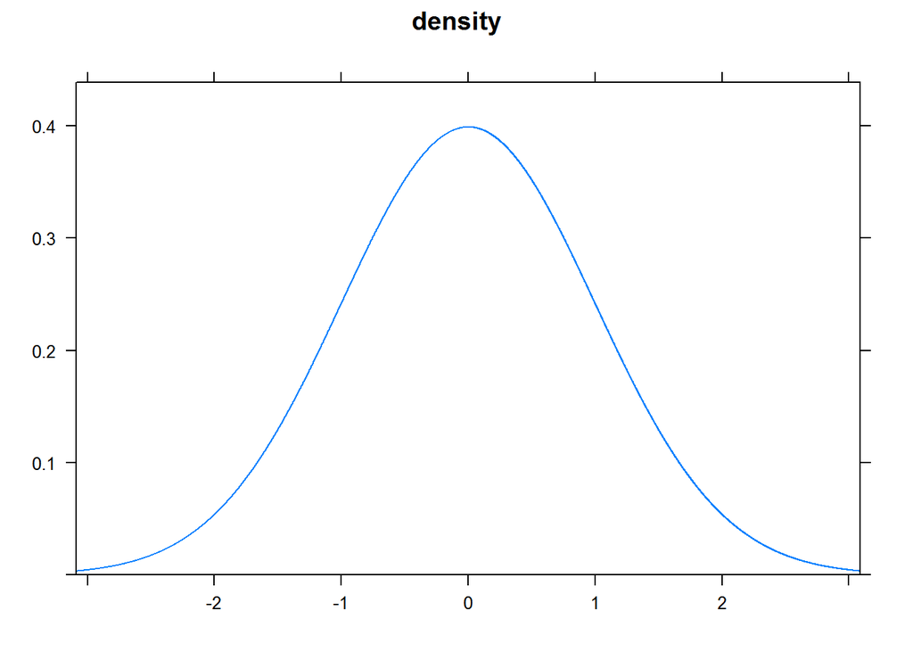

```r
plotDist('norm', mean=0, sd=1, kind='density',main='density')
```

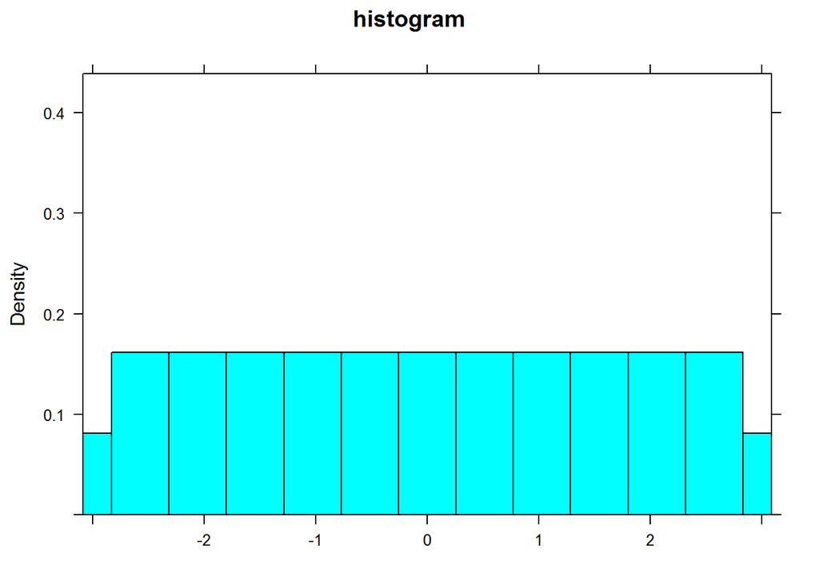

```r
plotDist('norm', mean=0, sd=1, kind='histogram',main='histogram')
```

plotDist can be used for discrete too.

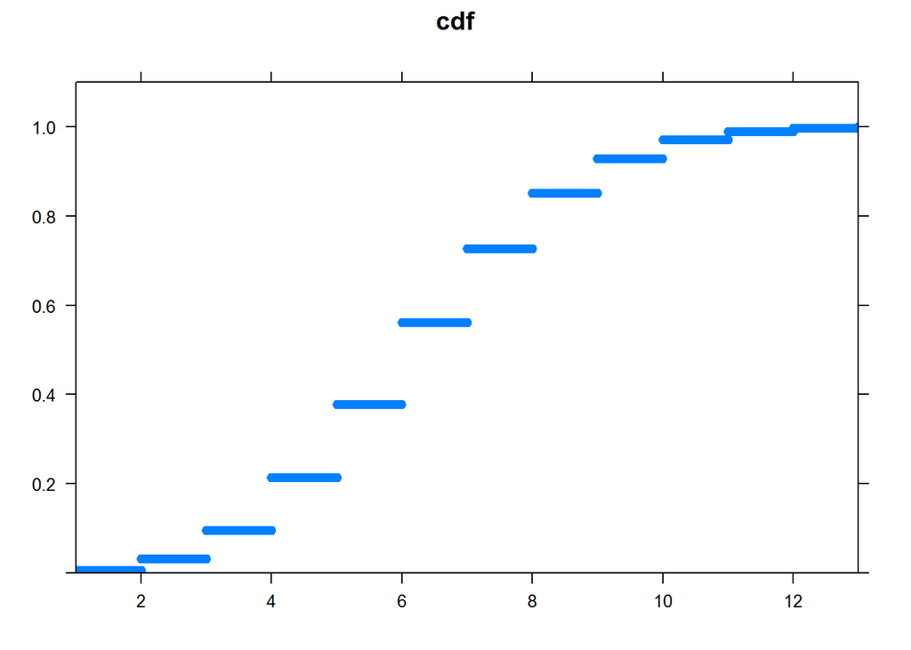

```r
plotDist('binom', size=25, prob=.25, kind='cdf',main='cdf')
```

[figure not shown]

```r
plotDist('binom', size=25, prob=.25, kind='qq',main='q-q')
```

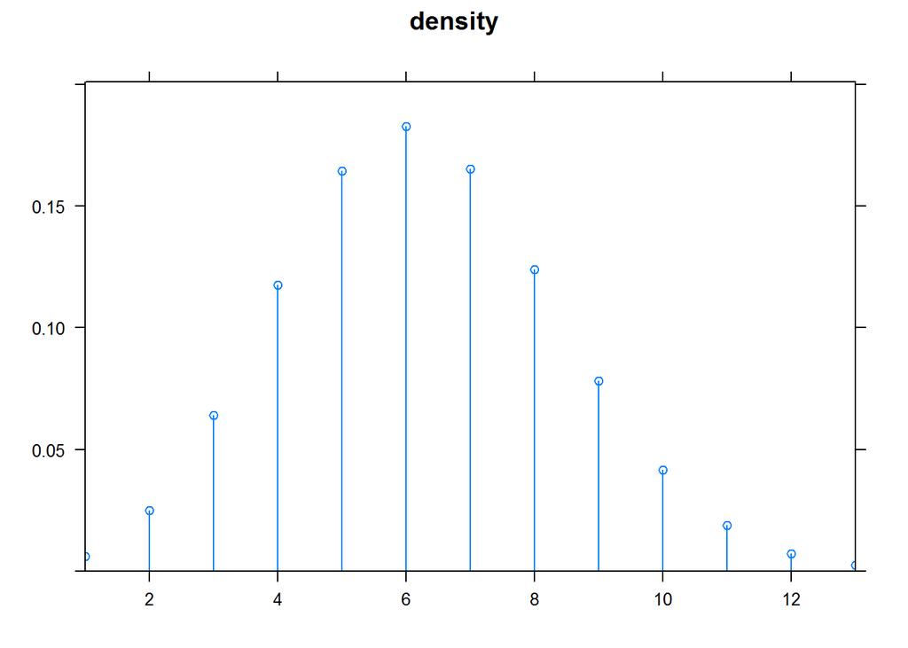

```r
plotDist('binom', size=25, prob=.25, kind='density',main='density')
```

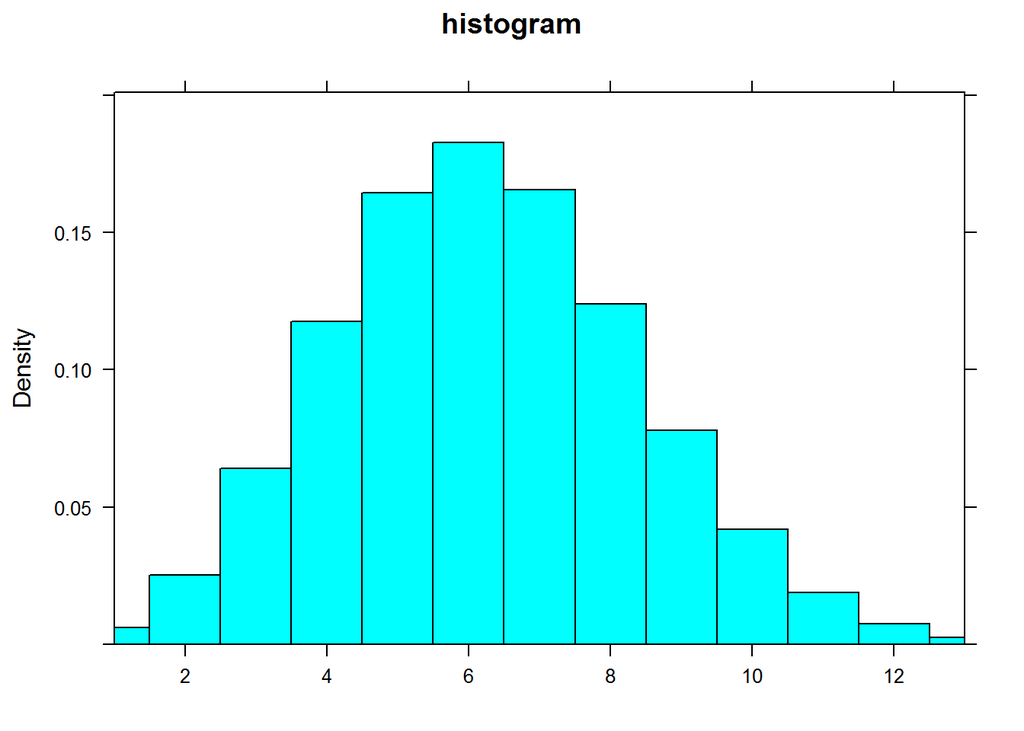

```r
plotDist('binom', size=25, prob=.25, kind='histogram',main='histogram')
```

Overlaying things:

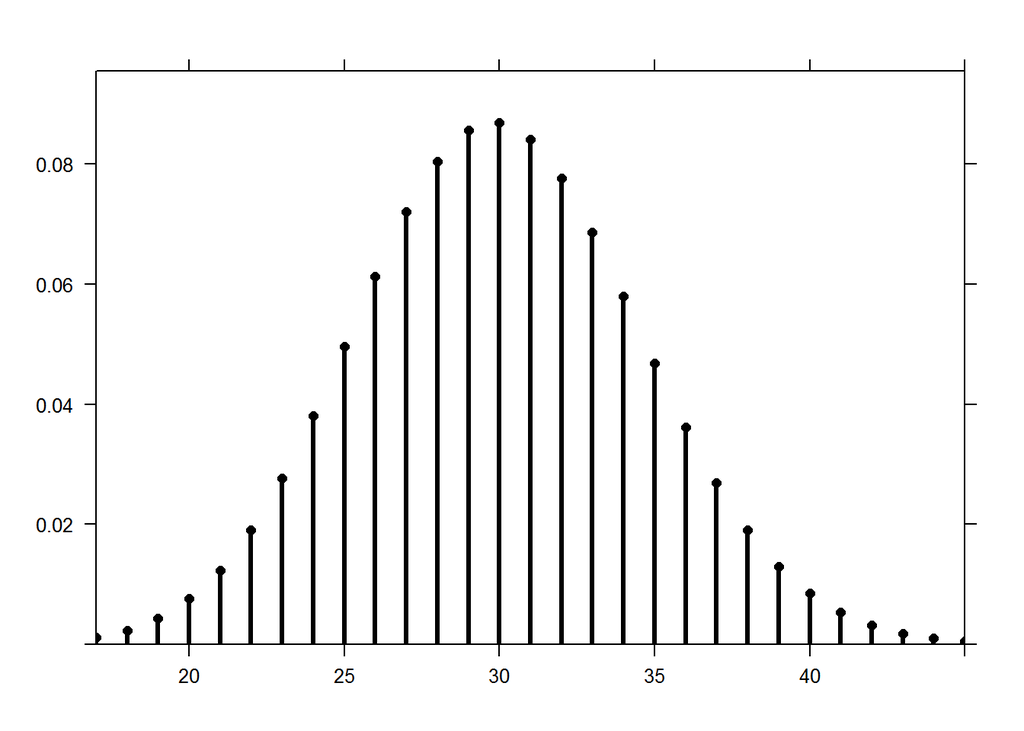

```r
plotDist("binom", size=100, prob=.3, col='black', lwd=3, pch=16)
```

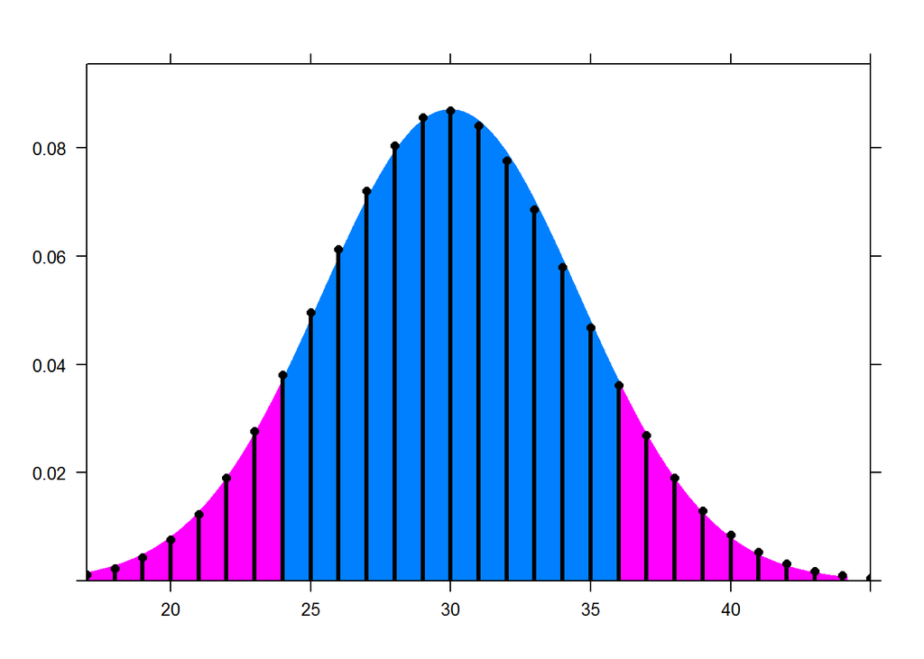

```r
plotDist("norm", mean=30, sd=sqrt(100*.3*.7), groups=abs(x-30)>6, type="h", under=TRUE)
```

Using fitdistr finds the distribution parameters based on a set of data. For example we generate 1000 standard normals and try fitting it to the normal distribution. The output is the estimated mean and standard deviation with their standard deviations.

```r
fitdistr(rnorm(1000),densfun = 'normal')
```

```
##       mean          sd
##   0.01962463   1.00804084
##  (0.03187705) (0.02254048)
```